# Painel IPCA — Inflação Brasileira

Análise mensal com dados do BCB e IBGE

Autor

Raimundo Casé — economista

Data de Publicação

11 de outubro de 2026

## 1 Introdução

O **Índice Nacional de Preços ao Consumidor Amplo (IPCA)** é o indicador oficial de inflação do Brasil, medido mensalmente pelo IBGE. Calculado com base em uma cesta de consumo de famílias com renda entre 1 e 40 salários mínimos nas principais regiões metropolitanas do país, o IPCA é a referência adotada pelo Banco Central na condução da política monetária pelo regime de metas de inflação, em vigor desde 1999.

A interpretação do IPCA exige múltiplas lentes temporais. A variação mensal revela o pulso imediato dos preços; o acumulado em doze meses é o horizonte pelo qual o Conselho Monetário Nacional (CMN) avalia o cumprimento da meta; o acumulado no ano captura a trajetória corrente; e a decomposição por grupos de despesa — Alimentação e Bebidas, Habitação, Transportes, entre outros — permite identificar de onde vem a pressão inflacionária. Este relatório organiza essas quatro perspectivas em painéis integrados, com dados direto do SGS/BCB (série 433 para o IPCA, série 13521 para a meta) e da API SIDRA/IBGE (tabela 7060 para os grupos).

Os dados mais recentes disponíveis são de **setembro de 2026**. Naquele mês, o IPCA registrou variação de **0.82%**, enquanto o acumulado em doze meses alcançou **4.58%** e o acumulado no ano chegou a **3.95%**. Ao longo das seções seguintes, esses números são contextualizados frente à meta vigente de **3.00%** (±1,5 p.p.) e ao comportamento histórico dos grupos de despesa.

## 2 Panorama Mensal

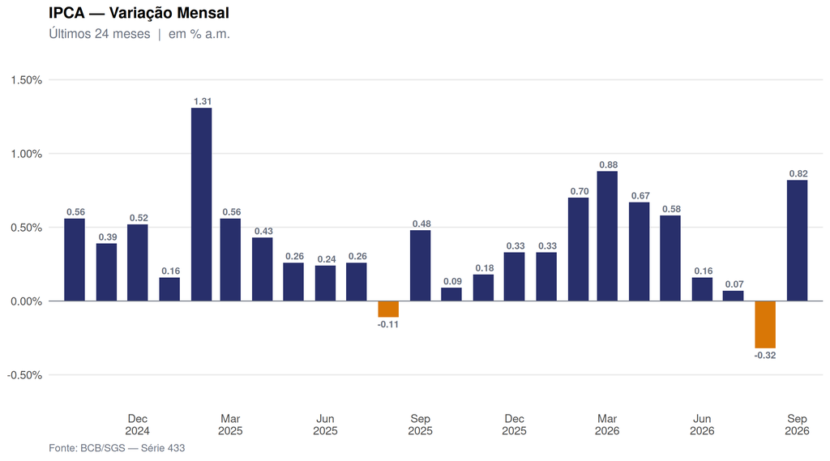

Figura 1: IPCA — variação mensal (últimos 24 meses, referência set/2026)

Em **set/2026**, o IPCA variou **0.82%**, resultado superior ao registrado em ago/2026 (-0.32%), uma diferença de **+1.14 p.p.**. O gráfico acima exibe as barras mensais dos últimos 24 meses em escala truncada para facilitar a leitura das variações, que em geral oscilam em frações de ponto percentual. Barras em azul-marinho indicam meses de inflação positiva; barras em âmbar, deflação.

A leitura isolada do mês corrente, embora relevante para acompanhar o ritmo de curto prazo, pode ser enganosa quando o IPCA apresenta forte componente sazonal — como ocorre tipicamente em março (reajuste de mensalidades escolares) e nos meses de energia elétrica. Por isso, a seção seguinte amplia o horizonte para o acumulado em 12 meses, que suaviza esses efeitos e oferece a visão sobre a qual o Banco Central calibra a taxa Selic.

## 3 Acumulado em 12 Meses e Meta

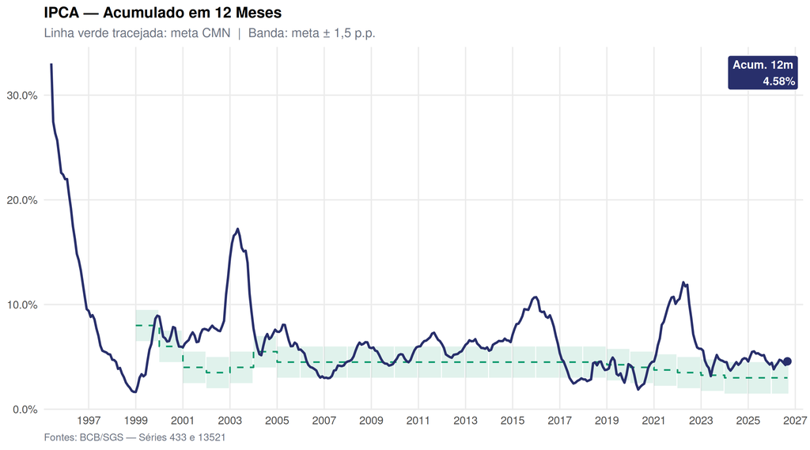

Figura 2: IPCA acumulado em 12 meses e meta do CMN com banda de tolerância (±1,5 p.p.)

O acumulado em doze meses atingiu **4.58%** em set/2026. A meta fixada pelo CMN para 2026 é de **3.00%**, com intervalo de tolerância entre **1.50%** e **4.50%**. O IPCA 12m está, portanto, **fora** da banda de tolerância. A faixa verde translúcida no gráfico marca essa banda; a linha tracejada, a meta central, que pode mudar de patamar ano a ano conforme as deliberações do CMN.

A série histórica evidencia os episódios em que o IPCA ultrapassou o teto — em particular o biênio 2021–2022, marcado pelos choques de energia, câmbio e commodities no pós-pandemia — e a subsequente desinflação que trouxe o índice de volta à vizinhança da meta. O gráfico apresenta a meta em degraus anuais (`geom_step`), sem interpolar entre valores de anos consecutivos, o que preserva a fidelidade à deliberação oficial: a meta é válida para o ano inteiro, não varia mês a mês.

A caixa no canto superior direito exibe o último valor disponível do IPCA 12m, facilitando a leitura imediata sem necessidade de inspecionar o eixo vertical. Esse recurso é especialmente útil quando o relatório é consultado rapidamente, como em reuniões do Copom ou apresentações de estratégia.

## 4 Sazonalidade

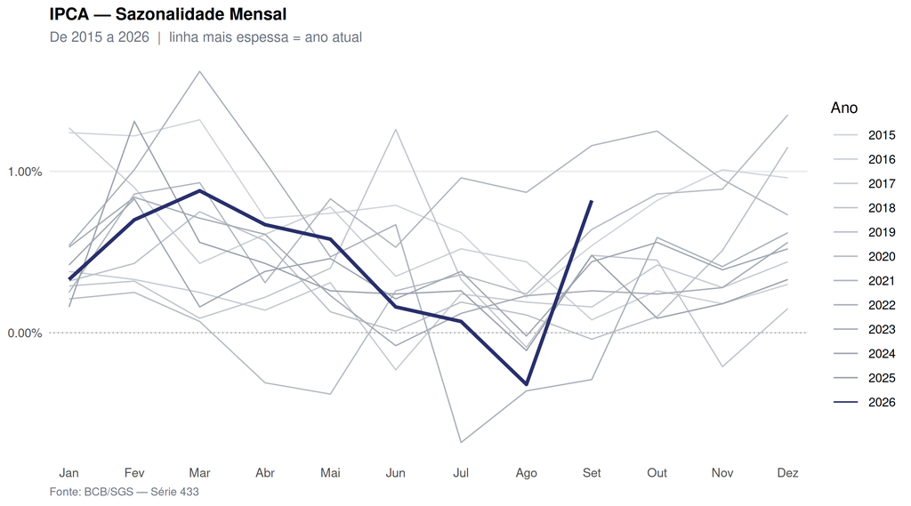

Figura 3: IPCA — sazonalidade mensal por ano (2015–2026)

O gráfico sazonal sobrepõe a trajetória mensal de cada ano — cada linha corresponde a um ano, o ano 2026 destacado em azul com traço mais espesso e os demais em gradiente de cinza. Esse formato permite identificar rapidamente se o padrão do ano corrente se assemelha ao de anos anteriores ou se apresenta desvio significativo, e em qual mês a divergência se manifesta.

Historicamente, o primeiro trimestre concentra as leituras mais elevadas, por conta do reajuste de mensalidades escolares (março), de tarifas de planos de saúde e de itens de alimentação com sazonalidade agrícola. O segundo semestre costuma apresentar alívio relativo, especialmente entre julho e setembro, antes de nova pressão típica de dezembro em itens como vestuário e lazer. Entender esse padrão ajuda a separar o componente sazonal do componente tendencial, um insumo fundamental para modelos de inflação no atacado e para projeções de curto prazo.

## 5 Contribuições por Grupo

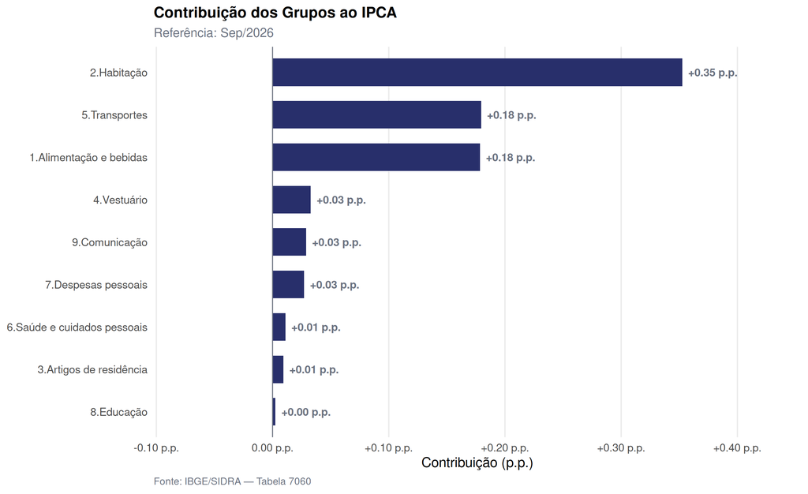

Figura 4: Contribuição ao IPCA por grupo de despesa — set/2026

Tabela 1: Contribuições e pesos por grupo — set/2026

| Grupo | Variação (% a.m.) | Peso (p.p.) | Contribuição (p.p.) |
| --- | --- | --- | --- |
| 2.Habitação | 2.31 | 15.26 | 0.3525 |
| 5.Transportes | 0.89 | 20.16 | 0.1794 |
| 1.Alimentação e bebidas | 0.83 | 21.51 | 0.1785 |
| 4.Vestuário | 0.71 | 4.62 | 0.0328 |
| 9.Comunicação | 0.64 | 4.51 | 0.0289 |
| 7.Despesas pessoais | 0.26 | 10.41 | 0.0271 |
| 6.Saúde e cuidados pessoais | 0.08 | 13.84 | 0.0111 |
| 3.Artigos de residência | 0.27 | 3.48 | 0.0094 |
| 8.Educação | 0.04 | 6.21 | 0.0025 |

Em set/2026, o grupo com **maior contribuição positiva** ao IPCA foi **2.Habitação** (+0.35 p.p.), enquanto **8.Educação** registrou a **menor contribuição** (+0.00 p.p.). A soma das contribuições dos nove grupos totaliza **0.82 p.p.**, o que deve aproximar-se da variação mensal do índice cheio (0.82%); qualquer discrepância acima de 0,05 p.p. sinaliza problema de consistência nos dados da API.

## 6 Encerramento

Este relatório consolidou quatro dimensões do IPCA de **setembro de 2026**:

| Indicador | Valor |
| --- | --- |
| Variação mensal | 0.82% |
| Acumulado no ano | 3.95% |
| Acumulado 12 meses | 4.58% |
| Meta CMN 2026 | 3.00% ± 1,5 p.p. |
| Maior contribuição do mês | 2.Habitação (+0.35 p.p.) |

O acumulado em 12 meses está **acima do teto da banda (4.50%)**. Do ponto de vista operacional, a trajetória do índice cheio reflete o balanço entre os grupos pressionados — especialmente Alimentação e Transportes, mais voláteis e sujeitos a choques de oferta — e os grupos mais inerciais, como Educação e Saúde, que tendem a reajustar contratos anualmente.

**NotaNotas metodológicas e fontes**

- **Série 433 / SGS-BCB**: IPCA — variação percentual mensal, divulgado pelo IBGE e disponibilizado no Sistema Gerenciador de Séries Temporais do Banco Central do Brasil. Acesso via pacote `rbcb`.
- **Série 13521 / SGS-BCB**: Meta de inflação fixada pelo CMN, em pontos percentuais ao ano.
- **Tabela 7060 / SIDRA-IBGE**: IPCA — variação mensal (variável 63) e peso mensal (variável 66) para os 9 grupos de despesa (classificação c315). Acesso via pacote `sidrar`.
- **Fórmula de acumulado**: $\prod_{i}(1 + x_i/100) - 1$, sem aproximação linear.
- **Fórmula de contribuição**: $\text{contrib}_i = \text{variação}_i \times \text{peso}_i / 100$; soma dos grupos ≈ IPCA cheio (diferenças por arredondamento da API).
- Relatório gerado em 11/10/2026 às 17:21.

**Boletim IPCA** — Semana de referência: 2026/10/11

Elaborado por Raimundo Casé — economista | economistacase@gmail.com

Fontes primárias: BCB — Banco Central do Brasil (Selic, Câmbio, IBC-Br) | IBGE — Instituto Brasileiro de Geografia e Estatística (IPCA).

*As análises e opiniões expressas neste boletim são de responsabilidade exclusiva do autor e não representam qualquer instituição.*